# flood_model_upt

Spencer Rhea

7/27/2020

# Ecoli Model Output

### Updated model including only ecoli sites on river (no reservoirs or lakes). I also lumped Boulder and Fort Collins because of their low number of sites and similar attributes. I only included model parameters that were significant, so NA values are not significant. One thing that changed by combining Boulder and Fort Collins is that now percent renters and percent of people with college degrees are significant. These results for Fort Collins and Boulder can be seen as a 1% increase in the percent of renters in an area will increase the ecoli concentration by 1.9%.

| Inputs Parameters | Fort Collins + Boulder | Denver Metro | Colorado Springs | Pueblo | Front Range |
| --- | --- | --- | --- | --- | --- |
| Intercept | NA | NA | -48.62 | NA | NA |
| Log Percent People of Color | NA | 2.04 | NA | 5.29 | 1.26 |
| Log Percent Renters | 1.94 | NA | 3.23 | NA | 0.69 |
| Log Median Income | NA | NA | NA | NA | NA |
| Log Percent Collage Degrees | -4.86 | 1.20 | NA | NA | NA |
| Ecoli Median conc | 38.00 | 63.00 | 791.00 | 222.00 | 131.00 |

# Flood Risk

### The First Street Foundation data for flooding risk was only available at a zip code level summary. So I plotted and ran simple linear models for relationship between the percent of properties in a zip code and the four demographic variables. All significant estimates (p-value less than 0.05) are included in the table below. I also included all of the plots as well. The table also includes the percent of properties in each city that are at risk of flooding.

### For some reason most of the zip codes in Pueblo were not included in the data I received from the First Street Foundation, so it may not be possible to draw conclusions about Pueblo.

| Input | Fort Collins + Boulder | Denver Metro | Colorado Springs | Pueblo | Front Range |
| --- | --- | --- | --- | --- | --- |
| Log Percent POC | -0.45 | -0.44 | NA | NA | -0.37 |
| Log Percent Renters | NA | -0.30 | NA | NA | -0.22 |
| Log Median Income | NA | NA | NA | NA | NA |
| Log Degrees | NA | -0.24 | NA | NA | NA |
| Percent of Properties with Flood Risk | 17.00 | 25.00 | 15 | 15 | 21.00 |

## Fort Collins and Boulder

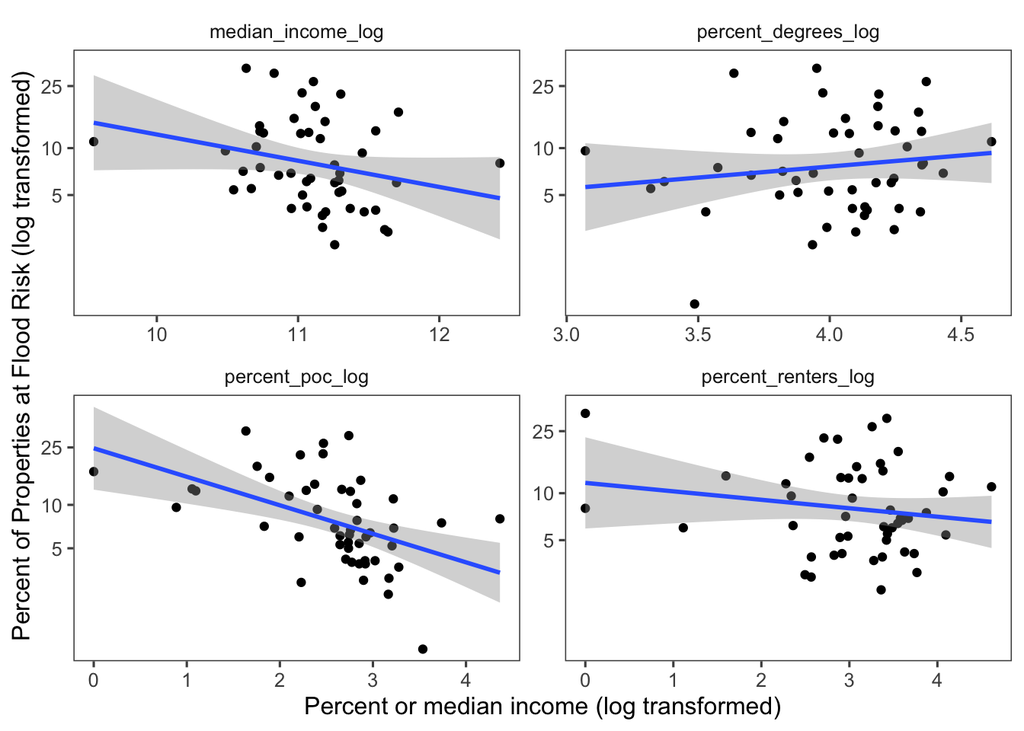

## Denver

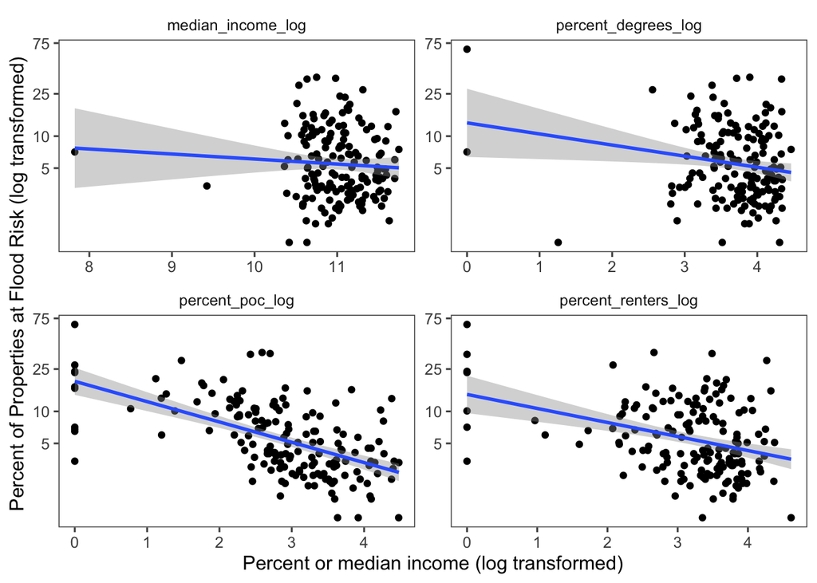

## Colorado Springs

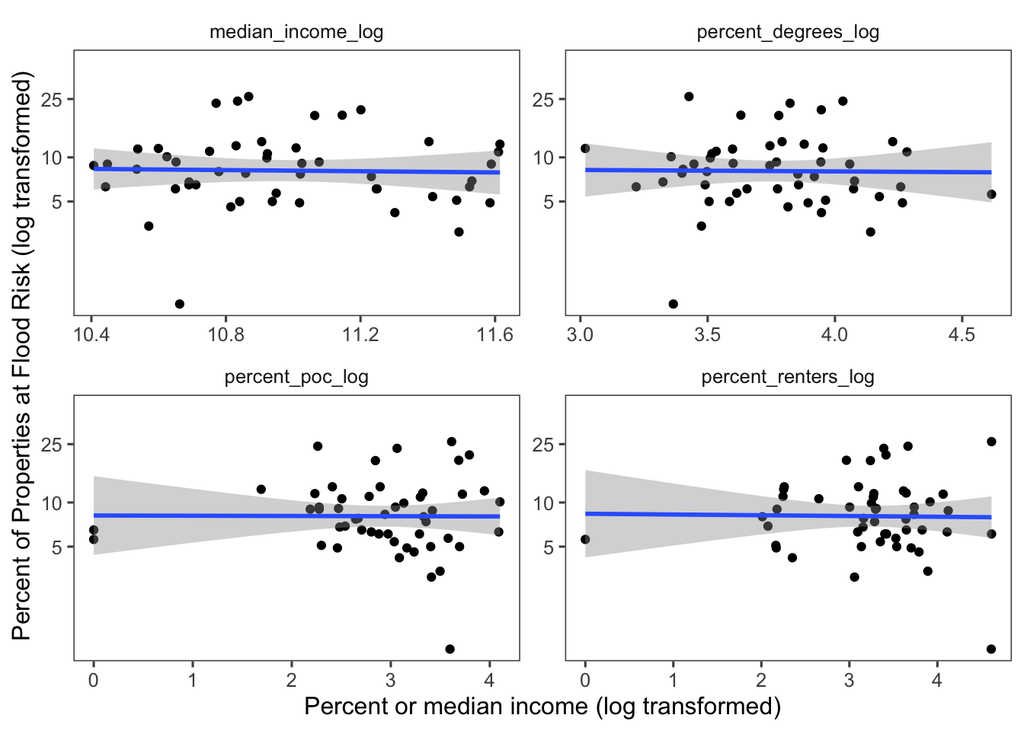

## Pueblo

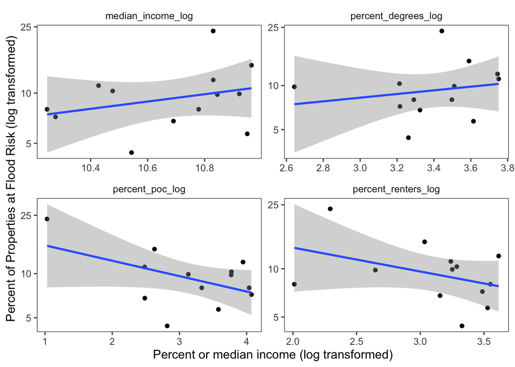

## Front Range

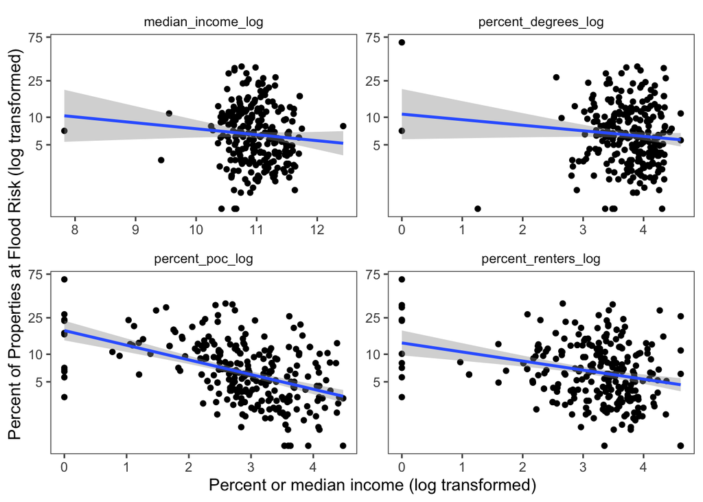